# Modèle logistique

Cheikh Talla

13/01/2020

## Modèle logistique simple

La regression logistique permet de lier une variable qualitative (plus souvent binaire) à une ou plusieurs variables $X_{1}, X_{2},...$ Application: La régression logistique est largement répandue dans de nombreux domaines. Exemple:

- En santé, elle permet par exemple de trouver les facteurs qui caractérisent un groupe de sujets malades par rapport à des sujets sains
- Dans le domaine de la banque, elle permet détecter les groupes à risque lors de la souscription d’un crédit.
- En fiabilité : survenu d’un accident sur une ligne de production

On cherche à expliquer une variable binaire Y à l’aide d’autres variables. On utilise le modèle suivant :

```r
library(InformationValue)
data <- read.csv2("/Users/Talla/Documents/COURS/Master ESP 2020 DIC1G2B/data_reglog.csv")
 head(data)
```

```
   x y
1 47 1
2 35 1
3 22 1
4 39 1
5 30 1
6 46 0
```

$x$ est l’âge de 40 personnes, et $y$ la variable indiquant si la persone est malade ou pas.

On constate que vraisemblablement, plus les personnes sont âgées, moins elles sont malades.

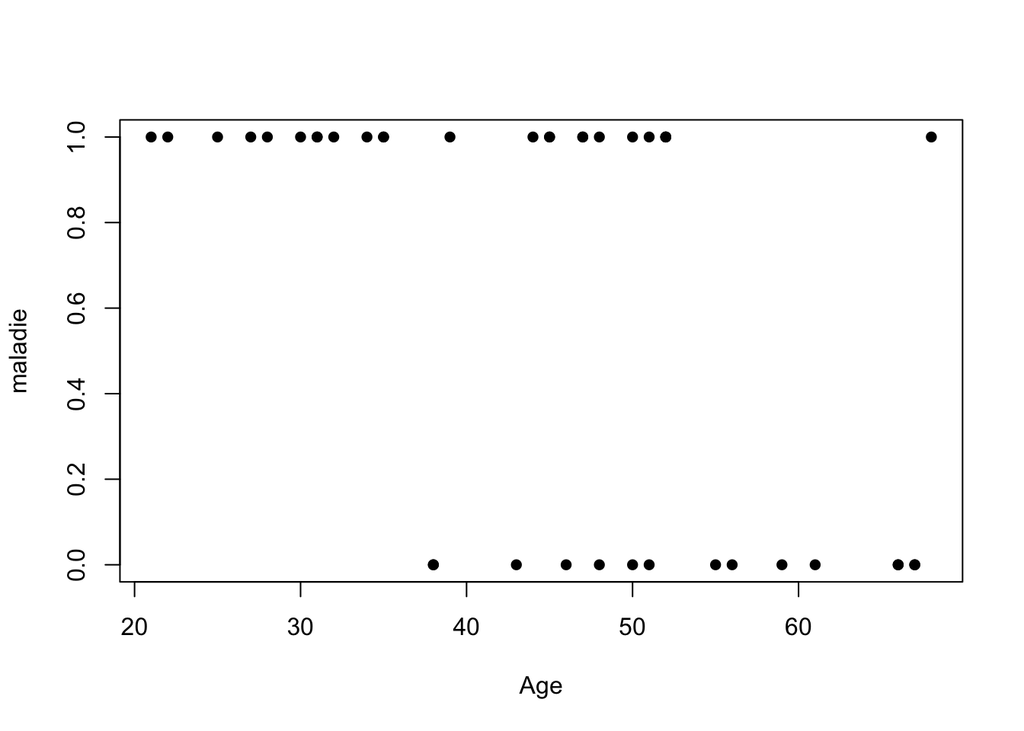

```r
plot(data$x,data$y, pch=16, xlab="Age", ylab="maladie")
```

La régression logistique est un cas particulier de Modèle Linéaire Généralisé (GLM).

Une première idée est de modéliser la probabilité d’être atteint de lamaladie par une régression linéaire avec une équation du type :
$$Y = aX + b$$
$P(maladie = 1) = a_{0} + a_{1} × age$

Mais ce modèle peut conduire à des probabilités prédites négatives ou supérieures à 1. On définit la foncton logit par la relation:
$$logit(p)= log(\dfrac{p}{1-p})$$

- $Y_{i}$ est une variable binaire qui est égale à 1 si $i$ est atteint de la maladie $0$ sinon.
- $p_{i}$ est la probabilité d’être atteint de la maladie
- $X$ est le facteur de risque (variable explicative)

Le modèle logistique correspondant est:

$$logit(p_{i})= a_{0} + a_{1}X$$
$$log(\dfrac{p_{i}}{1-p_{i}})= logit(p_{i}) =
a_{0} + a_{1}*age$$

Posons:
$$Z =a_{0} + a_{1}*age$$
alors
$$p_{i} =
\dfrac{e^{Z}}{1+e^{Z}}$$
$$p_{i} =
\dfrac{1}{1+e^{-Z}}$$

## Estimation des paramètres

- L’estimation des paramètres du modèle de régression logistique se fait par la méthode du maximum de vraisemblance.
- On maximise la vraisemblance par rapport aux paramètres $a_{0}, a_{1}, · · · , a_{p}$ au moyen d’un algorithme numérique
- Dans certains cas, l’algorithme ne peut proposer une estimation stable des paramètres.
- En pratique, il faut s’assurer que la procédure numérique a convergé vers des valeurs stables des paramètres.

### Tests de significativité des paramètres

Pour tester la significativité d’un coefficient $H_{0} : a_{1} = 0$ on utilise un test de Wald. Sous $H_{0}$,

$$\dfrac{\hat{a_{1}}^2}{\sqrt{V(\hat{a_{1})}}} \sim \chi^2(1)$$

Une absence d’association entre la variable binaire $Y$ et la variable $X$ se traduit par l’hypothèse $H_{0} : a_{1} = 0$.

### Odds-Ratio

|  | M (+) | NM(-) |
| --- | --- | --- |
| E (+) | $a$ | $b$ |
| NE (-) | $c$ | $d$ |

L’Odds-Ratio permet de mesurer l’association entre deux variables binaires.

$$OR =
\dfrac{\dfrac{a}{b}}{\dfrac{c}{d}}$$
**Interprétation** : Si $OR = 1$, dans notre exemple, la probabilité d’être malade est la même chez les exposés que chez les non exposés, donc le risque de maladie n’est pas associé à la variable Exposition.

Calculer l’Odds-Ratio ajusté : $OR = exp(a1)$

**Cas d’une seule variable exogène binaire:**

$$RC =
\dfrac{\dfrac{P(Y_{i}=1|X=1)}{1-P(Y_{i}=1|X=1)}}{\dfrac{P(Y_{i}=1|X=0)}{1-P(Y_{i}=1|X=0)}}$$

$$RC= \dfrac{e^{(a_{0} +
a_{1})}}{e^{(a_{0})}}$$
$$RC=
e^{(a_{1})}$$

- Avec l’estimateur de β1: $RC=exp(a_{1})$, permet de comparer les individus qui possèdent le symptôme X avec ceux qui ne le possède pas. Pour cela, on compare le RC à 1.
- L’estimateur de $a_{0}$: On peut se calculer C’est-à-dire la proportion observée de malades n’ayant pas le symptôme X
  $$P(Y_{i}
  =1|X=0)=\dfrac{e^{a_{0}}}{1+e^{a_{0}}}$$

**Cas d’une seule variable exogène quantitative:** Avec l’estimateur de $a_{0}$ permet de connaitre la proportion de malades dont la valeur de X est 0. Attention à l’interprétation de $a_{0}$ qui n’a pas de sens pour certaines variables X comme l’âge.

### Pratique

```r
myreg=glm(y~x,data=data, family=binomial(link=logit))
summary(myreg)
```

```
Call:
glm(formula = y ~ x, family = binomial(link = logit), data = data)

Deviance Residuals:
    Min       1Q   Median       3Q      Max
-1.8686  -0.7764   0.3801   0.8814   2.0253

Coefficients:
            Estimate Std. Error z value Pr(>|z|)
(Intercept)   5.9462     1.9599   3.034  0.00241 **
x            -0.1156     0.0397  -2.912  0.00360 **
---
Signif. codes:  0 '***' 0.001 '**' 0.01 '*' 0.05 '.' 0.1 ' ' 1

(Dispersion parameter for binomial family taken to be 1)

    Null deviance: 52.925  on 39  degrees of freedom
Residual deviance: 39.617  on 38  degrees of freedom
AIC: 43.617

Number of Fisher Scoring iterations: 5
```

On obtient donc le modèle suivant: $logit(E(Y))=−0.12X+5.95$

On constate que l’influence (négative) de l’âge sur La maladie est bien significative au seuil de 5%.

Si l’on représente cette relation entre $logit(E(Y)$ et $X$, on retrouve bien une relation linéaire. On procède à une transformation inverse de la relation:

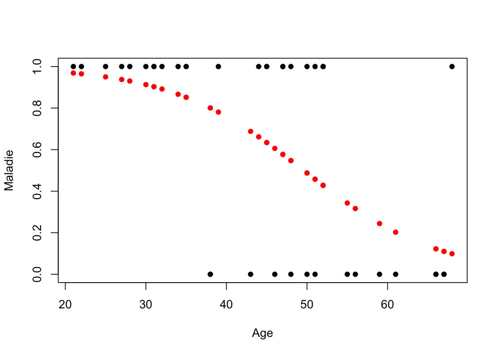

```r
logit_ypredit =  -0.12*data$x+5.95
ypredit = exp(logit_ypredit)/(1+ exp(logit_ypredit)) # transfo inverse de logit

plot(data$x,data$y , pch=16, xlab="Age", ylab="Maladie")
points(data$x,ypredit, col="red", pch=16)
```

Ici, étrangement, l’augmentation de l’âge d’une année, va réduire le risque de présence de maladie OR = EXP(-0.1156)=0.89.

Si on introduit une variable discréte, On peut mesurer directement le surcroît de risque qu’introduit chaque facteur explicatif (variable 1/0)

#### Prediction

```r
predicted1 <- predict(myreg, data, type="response")  # predicted scores
```

**Seuil de probabilité de prédiction optimal pour le modèle**

Le seuil par défaut de coupure est 0.5. Mais parfois, le réglage de la coupure de probabilité peut améliorer la précision de la validation. La fonction InformationValue :: optimalCutoff fournit des moyens de trouver le seuil optimal pour améliorer la prédiction des 1 et 0 et de réduire l’erreur de classification. Permet de calculer le score optimal qui minimise l’erreur de classification.

```r
library(InformationValue)
optCutOff <- optimalCutoff(data$y, predicted1)
```

#### Erreur de classification

Calcule le pourcentage d’erreur de classification.

```r
err <- misClassError(data$y, predicted1, threshold = optCutOff)
err
```

```
[1] 0.2
```

#### La courbe ROC (Receiver Operating Characteristics Curve)

La courbe ROC trace le pourcentage de vrais positifs correctement prédits par un modèle. Un bon modèle, lorsque la coupure est basse, elle devrait marquer davantage de réels 1 comme positifs et moins de 0 réels comme 1. Plus la zone sous la courbe ROC est grande, meilleure est la capacité prédictive du modèle.

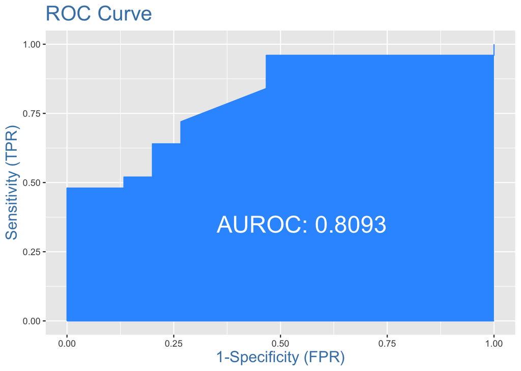

```r
plotROC(data$y, predicted1)
```

#### Concordance

Pour un modèle parfait, ce sera 100%. Ainsi, plus la concordance est élevée, meilleure est la qualité du modèle. La fonction suivante fournit le pourcentage de concordance et de discordance.

```r
Concordance(data$y, predicted1)
```

```
$Concordance
[1] 0.8053333

$Discordance
[1] 0.1946667

$Tied
[1] 0

$Pairs
[1] 375
```

#### Sensibilité et spécificité

```r
sensitivity(data$y, predicted1, threshold = optCutOff)
```

```
[1] 0.96
```

```r
specificity(data$y, predicted1, threshold = optCutOff)
```

```
[1] 0.5333333
```

```r
confusionMatrix(data$y, predicted1, threshold = optCutOff)
```

```
  0  1
0 8  1
1 7 24
```

## Régression logistique multiple

```r
data$sex <- factor(rep(c("M","F"),each=20))
names(data) <- c("age","maladie","sexe")
myreg=glm(maladie~age+sexe,data=data, family=binomial(link=logit))
summary(myreg)
```

```
Call:
glm(formula = maladie ~ age + sexe, family = binomial(link = logit),
    data = data)

Deviance Residuals:
    Min       1Q   Median       3Q      Max
-2.0063  -0.7269   0.2337   0.5686   1.5973

Coefficients:
            Estimate Std. Error z value Pr(>|z|)
(Intercept)  5.70194    2.10495   2.709  0.00675 **
age         -0.12789    0.04377  -2.922  0.00348 **
sexeM        2.04995    0.94065   2.179  0.02931 *
---
Signif. codes:  0 '***' 0.001 '**' 0.01 '*' 0.05 '.' 0.1 ' ' 1

(Dispersion parameter for binomial family taken to be 1)

    Null deviance: 52.925  on 39  degrees of freedom
Residual deviance: 33.885  on 37  degrees of freedom
AIC: 39.885

Number of Fisher Scoring iterations: 5
```

Dans le cadre d’un modèle logistique, généralement on ne présente pas les coefficients du modèle mais leur valeurs exponentielles qui correspondent à des odds ratio, également appelés rapports des cotes. L’odds ratio diffère du risque relatif. Cependent, l’interprétation est similaire.

```r
exp(coef(myreg))
```

```
(Intercept)         age       sexeM
299.4490966   0.8799527   7.7675308
```

```r
exp(confint(myreg))
```

```
                2.5 %       97.5 %
(Intercept) 8.4084277 4.070165e+04
age         0.7947671 9.478181e-01
sexeM       1.4224210 6.340668e+01
```

```r
exp(cbind(coef(myreg), confint(myreg)))
```

```
                            2.5 %       97.5 %
(Intercept) 299.4490966 8.4084277 4.070165e+04
age           0.8799527 0.7947671 9.478181e-01
sexeM         7.7675308 1.4224210 6.340668e+01
```

### Identifier les variables ayant un effet significatif

Les p-values associées aux odds ratios nous indique si un odd ratio est significativement différent de 1, par rapport à la modalité de référence. La fonction drop1 permet de tester l’effet global d’une variable. Elle va tour à tour supprimer chaque variable du modèle pour voir si la variance change significativement. Dans cette exemple ci-dessous la suppression d’une variable ne fait qu’augmenter la valeur de l’AIC.

```r
drop1(myreg, test = "Chisq")
```

```
Single term deletions

Model:
maladie ~ age + sexe
       Df Deviance    AIC     LRT  Pr(>Chi)
<none>      33.885 39.885
age     1   47.542 51.542 13.6569 0.0002194 ***
sexe    1   39.617 43.617  5.7325 0.0166535 *
---
Signif. codes:  0 '***' 0.001 '**' 0.01 '*' 0.05 '.' 0.1 ' ' 1
```

### Sélection de modèles

Lorsque l’on recherche les facteurs associés à un phénomène d’inclure un nombre important de variables explicatives potentielles dans un mmodèle logistique. Cependant, un tel modèle n’est pas forcément le plus efficace et certaines variables n’auront probablement pas d’effet significatif sur la variable d’intérêt.

Il faut également définir un critère pour déterminer la qualité d’un modèle. L’un des plus utilisés est le Akaike Information Criterion ou AIC. Plus l’AIC sera faible, meilleure sera le modèle.

```r
reg2 <- step(myreg)
```

```
Start:  AIC=39.88
maladie ~ age + sexe

       Df Deviance    AIC
<none>      33.885 39.885
- sexe  1   39.617 43.617
- age   1   47.542 51.542
```

Le modèle initial a un AIC de 39.88. Toute suppression d’une autre variable ferait que augmenter l’AIC.